# Cell Type Analysis

**Goal**: Identify and label cell types for each cluster in GBMSCTE Seurat objects.

## Load Libraries

```r
library(ggplot2)
library(SeuratObject)
library(Seurat)

library(dplyr)
library(conflicted)
conflict_prefer("select", "dplyr") ## required in %>% dplyr
```

```
## [conflicted] Will prefer dplyr::select over any other package
```

```r
set.seed(100)

print(getwd())
```

```
## [1] "C:/Users/Sam/Documents"
```

## PLot Known Cell Type Markers:GTE

### Load Data

```r
gte <- readRDS("D:\\backup files\\2021-11-11\\Cluster\\scratch\\gete-gbm\\results\\GBM-GSC neuroblastoma TE\\2021-09-02\\gte_gbmscIntUmap-subtypes.rds")
# ge <- readRDS("D:\\backup files\\2021-11-11\\Cluster\\scratch\\gete-gbm\\results\\GBM-GSC neuroblastoma TE\\2021-09-02\\gte_gbmscIntUmap-subtypes.rds")
```

```r
# DefaultAssay(gte) <- "integrated"
# DefaultAssay(ge) <- "integrated"
# DefaultAssay(gte) <- "RNA"
# DefaultAssay(ge) <- "RNA"
size = 5

colnames(gte@meta.data)
```

```
##  [1] "orig.ident"                 "nUMI"
##  [3] "nGene"                      "log10GenesPerUMI"
##  [5] "mitoRatio"                  "cells"
##  [7] "sample"                     "nCount_RNA"
##  [9] "nFeature_RNA"               "GBM_integrated_snn_res.0.8"
## [11] "GBM_seurat_clusters"        "neuro.ident"
## [13] "nCount_integrated"          "nFeature_integrated"
## [15] "integrated_snn_res.0.7"     "seurat_clusters"
## [17] "MGMTme"                     "sampleCombined"
## [19] "integrated_snn_res.0.2"     "integrated_snn_res.0.3"
## [21] "integrated_snn_res.0.4"     "integrated_snn_res.0.5"
## [23] "integrated_snn_res.0.6"     "teRatio"
## [25] "gbm_subtype"
```

```r
setwd("D:\\backup files\\getegbm\\gete-gbm\\results\\GBM-GSC neuroblastoma TE\\2022-11-07_celltypes_gbmscte")
  #run this line outside of a chunk
```

### UMAPs of Known Markers

Known Cell types markers from Velmeshev2019, Zhong 2018, Nowakowski2017, and discussions with Dr. Tanaka (Aug 2021)

```r
## Neural Progenitor Cells (NPCs) Early Development Markers
print(match(c("PAX6", "SOX2"), rownames(gte)))
```

```
## [1] 16607  6582
```

```r
p <- FeaturePlot(gte, features = c("PAX6", "SOX2"))
# ggsave("fig_gbmscte_gte_NPC-early.tiff", plot = p, units="in", width=size*2, height=size, dpi=300, compression = 'lzw')
```

```r
## NPCs Late Marker Genes
print(match(c("SFRP1", "RBFOX1", "HES1", "SOX2", "EMX2"), rownames(gte)))
```

```
## [1] 12995 22621  6722  6582 16023
```

```r
  #RBFOX1,2,3 all absent
print(match(c("SFRP1", "HRNBP1", "HES1", "SOX2", "EMX2"), rownames(gte)))
```

```
## [1] 12995    NA  6722  6582 16023
```

```r
  # A2BP1, FOX-1 HRNBP1 all absent

p <- FeaturePlot(gte, features = c("SFRP1", "HES1", "SOX2", "EMX2"))
# ggsave("fig_gbmscte_gte_NPC-late_RNA.tiff", plot = p, units="in", width=size*2, height=size*2, dpi=300, compression = 'lzw')
```

```r
## Excitatory Neurons Early Markers
print(match(c("NEUROD2"), rownames(gte)))
```

```
## [1] 24579
```

```r
p <- FeaturePlot(gte, features = c("NEUROD2"))
# ggsave("fig_gbmscte_gte_ExcN-early_RNA.tiff", plot = p, units="in", width=size, height=size, dpi=300, compression = 'lzw')
```

```r
## Excitatory Neurons Late Markers
print(match(c("NEUROD1", "NEUROD6", "SFRP1", "SLA", "NEUROD2", "HES1"), rownames(gte)))
```

```
## [1]  4520 11484 12995 13678 24579  6722
```

```r
p <- FeaturePlot(gte, features = c("NEUROD1", "NEUROD6", "SFRP1", "SLA", "NEUROD2", "HES1"))
# ggsave("fig_gbmscte_gte_ExcN-late_RNA.tiff", plot = p, units="in", width=size*2, height=size*3, dpi=300, compression = 'lzw')
```

```r
## Interneurons Early Markers
print(match(c("TTF1", "LHX6", "DLX1", "DLX2", "CALB2", "SST"), rownames(gte)))
```

```
## [1] 14833 14639  4419  4420 23458  6678
```

```r
p <- FeaturePlot(gte, features = c("TTF1", "LHX6", "DLX1", "DLX2", "CALB2", "SST"))
# ggsave("fig_gbmscte_gte_InterN-early.tiff", plot = p, units="in", width=size*2, height=size*3, dpi=300, compression = 'lzw')
```

```r
## Interneurons Late Markers
print(match(c("GAD1", "GAD2", "PDE4DIP", "LHX6", "DLX1", "CALB2", "CCK", "VIP", "PVALB"), rownames(gte)))
```

```
## [1]  4406 15226  1665 14639  4419 23458  5433 10969 29681
```

```r
p <- FeaturePlot(gte, features = c("GAD1", "GAD2", "PDE4DIP", "LHX6", "DLX1", "CALB2", "CCK", "VIP", "PVALB"))
# ggsave("fig_gbmscte_gte_InterN-late.tiff", plot = p, units="in", width=size*2, height=size*2, dpi=300, compression = 'lzw')
```

```r
## OPC Markers
print(match(c("OLIG1", "OLIG2", "SOX10", "SOX2", "YY1", "ZNF24", "ASCL1", "PDGFRA", "HES5", "COL20A1", "PMP2"), rownames(gte)))
```

```
##  [1] 29011 29009 29720  6582 21095 25823 19121  7204    98 28797 13306
```

```r
p <- FeaturePlot(gte, features = c("OLIG1", "OLIG2", "SOX10", "SOX2", "YY1", "ZNF24", "ASCL1", "PDGFRA", "HES5", "COL20A1", "PMP2"))
# ggsave("fig_gbmscte_gte_OPC_RNA.tiff", plot = p, units="in", width=size*4, height=size*3, dpi=300, compression = 'lzw')
```

```r
## Oligodendrocytes
print(match(c("MYRF", "MBP", "MOG", "PLP1"), rownames(gte)))
```

```
## [1] 16889 26121  9925 30585
```

```r
p <- FeaturePlot(gte, features = c("MYRF", "MBP", "MOG", "PLP1"))
# ggsave("fig_gbmscte_gte_OLIG_RNA.tiff", plot = p, units="in", width=size*2, height=size*2, dpi=300, compression = 'lzw')
```

```r
## Astrocytes
print(match(c("GFAP", "AQP4", "SLCO1C1", "SLC1A2"), rownames(gte)))
```

```
## [1] 24776 25764 18221 16648
```

```r
p <- FeaturePlot(gte, features = c("GFAP", "AQP4", "SLCO1C1", "SLC1A2"))
# ggsave("fig_gbmscte_gte_Ast_RNA.tiff", plot = p, units="in", width=size*2, height=size*2, dpi=300, compression = 'lzw')
```

```r
## Microglia early + late development
print(match(c("P2RY12", "PTPRC", "C1QB", "CD68", "TREM2", "GPR34", "CSF1R", "CXCR1"), rownames(gte)))
```

```
## [1]  6378  2366   419 24023 10209 30210  9230  4810
```

```r
p <- FeaturePlot(gte, features = c("P2RY12", "PTPRC", "C1QB", "CD68", "TREM2", "GPR34", "CSF1R", "CXCR1"))
# ggsave("fig_gbmscte_gte_MGlia_earlylate_RNA.tiff", plot = p, units="in", width=size*2, height=size*2, dpi=300, compression = 'lzw')
```

```r
## Outer Radial Glia- early-late
print(match(c("HOPX", "FAM107A", "TNC", "PAX6", "VIM", "ZIC2", "SLC7A11", "MTOR", "DAB1","LAMP5", "IL13RA2"), rownames(gte)))
```

```
##  [1]  7234  5744 14597 16607 15157 20058  7698   235  1028 28166 30644
```

```r
p <- FeaturePlot(gte, features = c("HOPX", "FAM107A", "TNC", "PAX6", "VIM", "ZIC2", "SLC7A11", "MTOR", "DAB1","LAMP5", "IL13RA2"))
# ggsave("fig_gbmscte_gte_oRG_RNA.tiff", plot = p, units="in", width=size*4, height=size*3, dpi=300, compression = 'lzw')
```

```r
## Ventral Radial glia Progenitor cells
print(match(c("DLX1", "DLX2", "FLRT2", "LIX1"), rownames(gte)))
```

```
## [1]  4419  4420 20939  8722
```

```r
p <- FeaturePlot(gte, features = c("DLX1", "DLX2", "FLRT2", "LIX1"))
# ggsave("fig_gbmscte_gte_vRGprogenitor_RNA.tiff", plot = p, units="in", width=size*2, height=size*2, dpi=300, compression = 'lzw')
```

```r
## Cortical ventral radial glia
print(match(c("PAX6", "VIM", "ZIC2", "HOPX"), rownames(gte)))
```

```
## [1] 16607 15157 20058  7234
```

```r
p <- FeaturePlot(gte, features = c("PAX6", "VIM", "ZIC2", "HOPX"))
# ggsave("fig_gbmscte_gte_vRG_RNA.tiff", plot = p, units="in", width=size*2, height=size*2, dpi=300, compression = 'lzw')
```

```r
## IPC (Intermediate precursor cells) - early
print(match(c("NHLH1", "SLC1A3"), rownames(gte)))
```

```
## [1] 2006 8269
```

```r
p <- FeaturePlot(gte, features = c("NHLH1", "SLC1A3"))
# ggsave("fig_gbmscte_gte_IPC_early_RNA.tiff", plot = p, units="in", width=size*2, height=size, dpi=300, compression = 'lzw')
```

```r
## IPC (Intermediate precursor cells) - late
print(match(c("ASCL1", "NHLH2", "TP53I11", "PPP1R17", "ADRA2A", "LTBP1"), rownames(gte)))
```

```
## [1] 19121  1535 16700 11486 15967  3308
```

```r
p <- FeaturePlot(gte, features = c("ASCL1", "NHLH2", "TP53I11", "PPP1R17", "ADRA2A", "LTBP1"))
# ggsave("fig_gbmscte_gte_IPC_late_RNA.tiff", plot = p, units="in", width=size*2, height=size, dpi=300, compression = 'lzw')
```

```r
## Ventral IPC (Intermediate precursor cells)
print(match(c("FLRT2", "DLX1", "DLX2", "DLX5", "DLX6"), rownames(gte)))
```

```
## [1] 20939  4419  4420 11929 11928
```

```r
p <- FeaturePlot(gte, features = c("FLRT2", "DLX1", "DLX2", "DLX5", "DLX6"))
# ggsave("fig_gbmscte_gte_ventralIPC_RNA.tiff", plot = p, units="in", width=size*2, height=size*3, dpi=300, compression = 'lzw')
```

```r
## dorsal IPC (Intermediate precursor cells)
print(match(c("PAX6", "ZIC2", "EOMES", "ASCL1", "SSTR2"), rownames(gte)))
```

```
## [1] 16607 20058  5326 19121 25207
```

```r
p <- FeaturePlot(gte, features = c("PAX6", "ZIC2", "EOMES", "ASCL1", "SSTR2"))
# ggsave("fig_gbmscte_gte_dorsalIPC_RNA.tiff", plot = p, units="in", width=size*2, height=size*3, dpi=300, compression = 'lzw')
```

```r
## Endothelial Cells
print(match(c("FLT1", "VWF", "FN1"), rownames(gte)))
```

```
## [1] 19658 17966  4775
```

```r
p <- FeaturePlot(gte, features = c("FLT1", "VWF", "FN1"))
# ggsave("fig_gbmscte_gte_Endothelial_RNA.tiff", plot = p, units="in", width=size*2, height=size*2, dpi=300, compression = 'lzw')
```

```r
## T-cells
print(match(c("CD3E", "CD8A"), rownames(gte)))
```

```
## [1] 17646  3788
```

```r
p <- FeaturePlot(gte, features = c("CD3E", "CD8A"))
# ggsave("fig_gbmscte_gte_Tcells_RNA.tiff", plot = p, units="in", width=size*2, height=size, dpi=300, compression = 'lzw')
```

```r
## Blood Cells
print(match(c("HBB"), rownames(gte)))
```

```
## [1] 16339
```

```r
p <- FeaturePlot(gte, features = c("HBB"))
# ggsave("fig_gbmscte_gte_Blood_RNA.tiff", plot = p, units="in", width=size, height=size, dpi=300, compression = 'lzw')
```

2022-11-11: Test Nowakowski 2017 oRG marker genes + Pollen2015 oRG marker Genes

```r
## Outer Radial Glia- Nowakowski.2017
print(match(c("MTOR", "RPS6", "DAB1", "LAMP5", "IL13RA2", "GLI2", "GFAP"), rownames(gte)))
```

```
## [1]   235 13968  1028 28166 30644  4113 24776
```

```r
p <- FeaturePlot(gte, features = c("MTOR", "RPS6", "DAB1", "LAMP5", "IL13RA2", "GLI2", "GFAP"))
# ggsave("fig_gbmscte_gte_oRG_RNA_Nowakowski2017.tiff", plot = p, units="in", width=size*3, height=size*3, dpi=300, compression = 'lzw')
```

```r
## ventricular Radial Glia- Nowakowski.2017
print(match(c("NEUROG2", "NEUROD6", "NEUROD1", "HMGA2", "NFATC2", "STMN2", "ELAVL4"), rownames(gte)))
```

```
## [1]  7580 11484  4520 18837 28650 13280   929
```

```r
p <- FeaturePlot(gte, features = c("NEUROG2", "NEUROD6", "NEUROD1", "HMGA2", "NFATC2", "STMN2", "ELAVL4"))
# ggsave("fig_gbmscte_gte_vRG_RNA_Nowakowski2017.tiff", plot = p, units="in", width=size*3, height=size*3, dpi=300, compression = 'lzw')
```

```r
##Radial Glia- Nowakowski.2017
print(match(c("EMX1", "NKX2-1"), rownames(gte)))
```

```
## [1]  3648 20456
```

```r
p <- FeaturePlot(gte, features = c("EMX1", "NKX2-1"))
# ggsave("fig_gbmscte_gte_RG_RNA_Nowakowski2017.tiff", plot = p, units="in", width=size*2, height=size, dpi=300, compression = 'lzw')
```

```r
## Radial Glia- Pollen.2015
print(match(c("SLC1A3", "PAX6", "SOX2", "PDGFD", "GLI3", "VIM", "HES1"), rownames(gte)))
```

```
## [1]  8269 16607  6582 17493 11571 15157  6722
```

```r
p <- FeaturePlot(gte, features = c("SLC1A3", "PAX6", "SOX2", "PDGFD", "GLI3", "VIM", "HES1"))
# ggsave("fig_gbmscte_gte_RG_RNA_Pollen2015.tiff", plot = p, units="in", width=size*3, height=size*3, dpi=300, compression = 'lzw')
```

```r
p <- FeaturePlot(gte, features = "CRYAB")
# ggsave("fig_gbmscte_gte_CRYAB_RNA_Pollen2015.tiff", plot = p, units="in", width=size, height=size, dpi=300, compression = 'lzw')
```

```r
## oRG (MOXD1), vRG (FBXO32) Pollen 2015
print(match(c("MOXD1", "FBXO32"), rownames(gte)))
```

```
## [1] 10788 13603
```

```r
p <- FeaturePlot(gte, features = c("MOXD1", "FBXO32"))
# ggsave("fig_gbmscte_gte_oRGvRG_RNA_Pollen2015.tiff", plot = p, units="in", width=size*2, height=size, dpi=300, compression = 'lzw')
```

EOMES was not detected in IPC’s normalized values.

```r
## IPC Markers (Close2017)
print(match(c("EOMES", "PAX6", "HOPX", "VIM"), rownames(gte)))
```

```
## [1]  5326 16607  7234 15157
```

```r
p <- FeaturePlot(gte, features = c("EOMES", "PAX6", "HOPX", "VIM"))
# ggsave("fig_gbmscte_gte_IPC-Close2017.tiff", plot = p, units="in", width=size*2, height=size*2, dpi=300, compression = 'lzw')
```

Normalized values show that none of the genes expressed here are significantly expressed.

```r
## Interneurons (Close2017)
print(match(c("PVALB", "VIP", "HTR3A", "SST", "NPY", "CALB2", "CCK", "RELN", "NOS1"), rownames(gte)))
```

```
## [1] 29681 10969 17589  6678 11389 23458  5433 12076 19306
```

```r
p <- FeaturePlot(gte, features = c("PVALB", "VIP", "HTR3A", "SST", "NPY", "CALB2", "CCK", "RELN", "NOS1"))
# ggsave("fig_gbmscte_gte_Interneurons-Close2017.tiff", plot = p, units="in", width=size*3, height=size*3, dpi=300, compression = 'lzw')
```

### Plots Summarizing Cell types

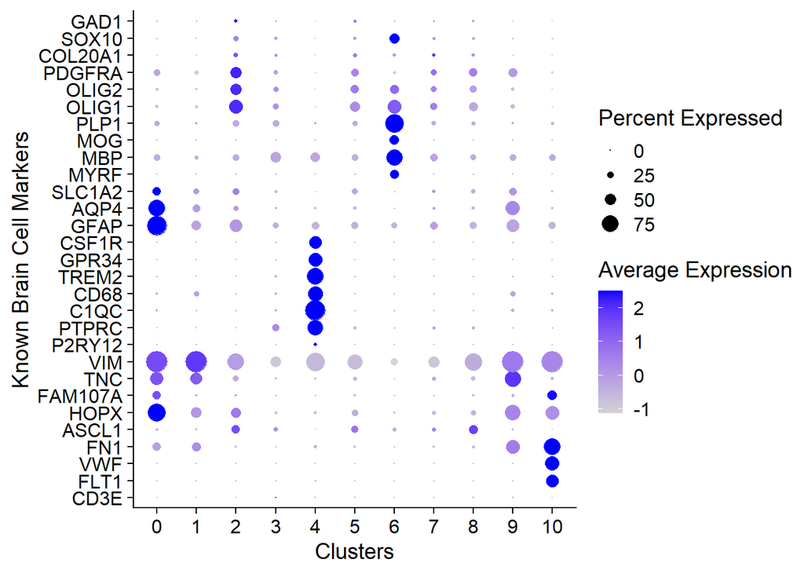

```r
DefaultAssay(gte) <- "RNA"
features = c(#"HBB", #Blood
              "CD3E", #T-cells
             "FLT1", "VWF", "FN1", #Endothelial
             "ASCL1", # IPC-late (?)
             "HOPX", "FAM107A", "TNC", "VIM", #orG
              "P2RY12", "PTPRC", "C1QC", "CD68", "TREM2", "GPR34", "CSF1R", #Microglia
              "GFAP", "AQP4", "SLC1A2", #Astrocytes
              "MYRF", "MBP", "MOG", "PLP1", #Oligodendrocytes
              "OLIG1", "OLIG2", "PDGFRA", "COL20A1", "SOX10",  #OPC
              "GAD1" #Interneurons
            # "HES1" #NPC
             )

p <- DotPlot(gte, features = features) +
      xlab("Known Brain Cell Markers") + ylab("Clusters") + coord_flip()
p
```

```r
# ggsave("fig_gbmscte_gte_dotplot_summary_rna.tiff", plot = p, units="in", width=size*1.1, height=size*1.1, dpi=300, compression = 'lzw')
```

I should be looking at the average normalized RNA expression across clusters instead of the raw RNA count, because the RNA would have batch effects.

```r
DefaultAssay(gte) <- "integrated"
features <- c(#"HBB", #Blood
              "CD3E", #"CD8A", #T-cells
              "FLT1", "VWF", "FN1", #Endothelial
              #"ASCL1", # IPC-late (?)
              #"PVALB", "SST", "GAD1", # Differentiated Cortical Interneurons (Inhibitory neurons)
              "MKI67", "MCM6", "TOP2A", "PCNA",  #Proliferating Cell Type
              "PTPRC", "C1QC", "CD68", "TREM2", "GPR34", "CSF1R", "CX3CR1", #Microglia,
                #"P2RY12", "HEXB" were absent
              "GFAP", "AQP4", "HOPX", "SLC1A2", #Astrocytes
              "MYRF", "MBP", "MOG", "PLP1", #Oligodendrocytes
              "OLIG1", "OLIG2", "PDGFRA", "SOX10"  #OPC, "COL20A1" was absent
              #"HES1" #NPC
             )

p <- DotPlot(gte, features = features) +   scale_colour_gradient2() +
      xlab("Known Brain Cell Markers") + ylab("Clusters") + coord_flip()
```

```
## which will replace the existing scale.
```

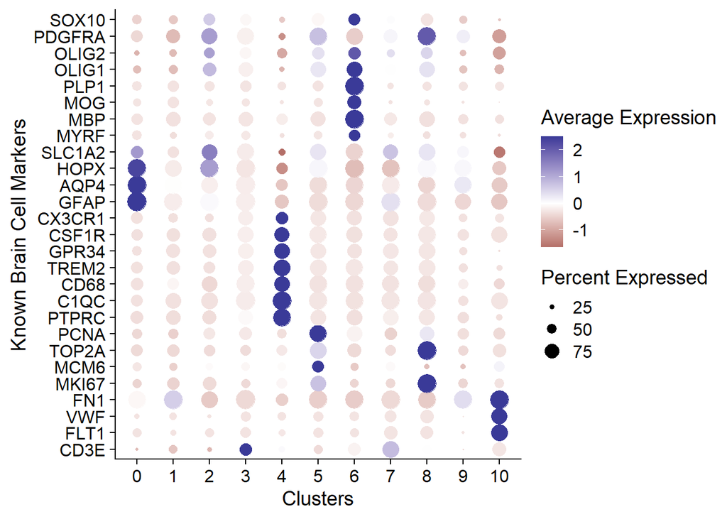

```r
p
```

```r
# ggsave("fig_gbmscte_gte_dotplot_summary_int.tiff", plot = p, units="in", width=size*1.1, height=size*1.2, dpi=300, compression = 'lzw')
```

Use the same marker genes on other PCA resolutions.

```r
#Dotplot for PC20r0.4
DefaultAssay(gte) <- "integrated"
print(head(gte@active.ident))
```

```
## GBM_AAACCTGCAATTCCTT-1 GBM_AAACCTGCACAGAGGT-1 GBM_AAACCTGGTGTGGCTC-1
##                      1                      4                      0
## GBM_AAACGGGGTCCGAATT-1 GBM_AAACGGGTCGAATGGG-1 GBM_AAAGATGGTCTCAACA-1
##                      0                      2                      2
## Levels: 0 1 2 3 4 5 6 7 8 9 10
```

```r
gte <- SetIdent(gte, value = gte@meta.data$integrated_snn_res.0.4)
print(head(gte@active.ident))
```

```
## GBM_AAACCTGCAATTCCTT-1 GBM_AAACCTGCACAGAGGT-1 GBM_AAACCTGGTGTGGCTC-1
##                      1                      5                      0
## GBM_AAACGGGGTCCGAATT-1 GBM_AAACGGGTCGAATGGG-1 GBM_AAAGATGGTCTCAACA-1
##                      0                      3                      2
## Levels: 0 1 2 3 4 5 6 7 8 9 10 11 12 13
```

```r
features <- c(#"HBB", #Blood
              "CD3E", #"CD8A", #T-cells
              "FLT1", "VWF", "FN1", #Endothelial
              #"ASCL1", # IPC-late (?)
              #"PVALB", "SST", "GAD1", # Differentiated Cortical Interneurons (Inhibitory neurons)
              "MKI67", "MCM6", "TOP2A", "PCNA",  #Proliferating Cell Type
              "PTPRC", "C1QC", "CD68", "TREM2", "GPR34", "CSF1R", "CX3CR1", #Microglia,
                #"P2RY12", "HEXB" were absent
              "GFAP", "AQP4", "HOPX", "SLC1A2", #Astrocytes
              "MYRF", "MBP", "MOG", "PLP1", #Oligodendrocytes
              "OLIG1", "OLIG2", "PDGFRA", "SOX10"  #OPC, "COL20A1" was absent
              #"HES1" #NPC
             )

p <- DotPlot(gte, features = features) +   scale_colour_gradient2() +
      xlab("Known Brain Cell Markers") + ylab("Clusters") + coord_flip()
```

```
## which will replace the existing scale.
```

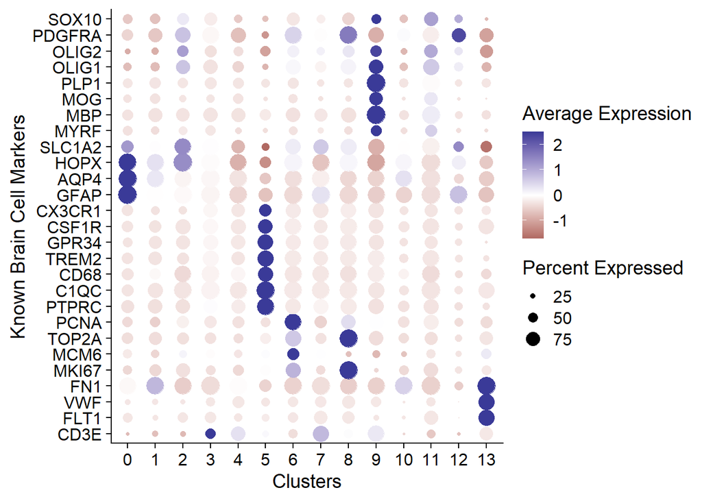

```r
print(p)
```

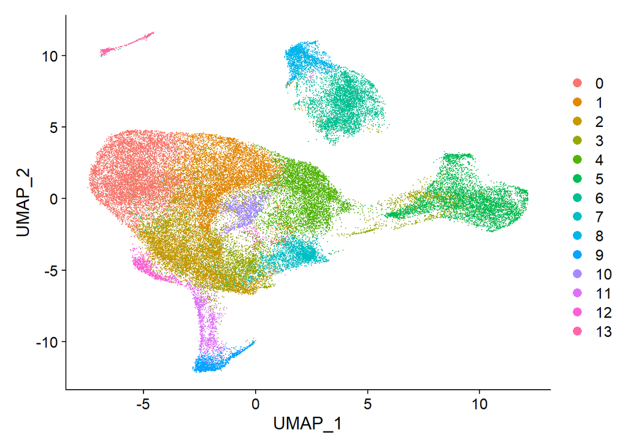

```r
# ggsave("fig_gbmscte_gte_PC20r04_dotplot_summary_int.tiff", plot = p, units="in", width=size*1.1, height=size*1.2, dpi=300, compression = 'lzw')

p <- UMAPPlot(gte)
print(p)
```

```r
# ggsave("fig_gbmscte_gte_PC20r04_UMAP.tiff", plot = p, units="in", width=size*1.2, height=size*1, dpi=300, compression = 'lzw')
```

```r
# Dotplot for RG, oRG, and vRG
DefaultAssay(gte) <- "integrated"
features.RG <- c(#"VIM", "SOX2", "SLC1A3", "HES1", "PAX6", "GLI3", "PDGFD", #RG -- from Pollen2015,
                 "GFAP", "VIM", "SOX2", "HES1", "PAX6", #RG (only those present in normalized assay)
                 "TNC", "PTPRZ1", "FAM107A", "HOPX", #oRG -- "LIFR", RPS6 not present, Pollen2015 & Nowakowski2017, respectively.
                 #"DAB1", #oRG + vRG not present Nowakowski2017
                 "CRYAB", "TAGLN2", "FBXO32", "LIX1" #vRG -- PDGFD, PALLD NFATC2 were absent (Pollen2015), and "STMN2", "ELAVL4" were targeting other cell types (oligodendrocyte cluster 8) (Nowakowski2017)
                 )
p <- DotPlot(gte, features = features.RG) +   scale_colour_gradient2() +
      xlab("Known Brain Cell Markers") + ylab("Clusters") + coord_flip()
```

```
## which will replace the existing scale.
```

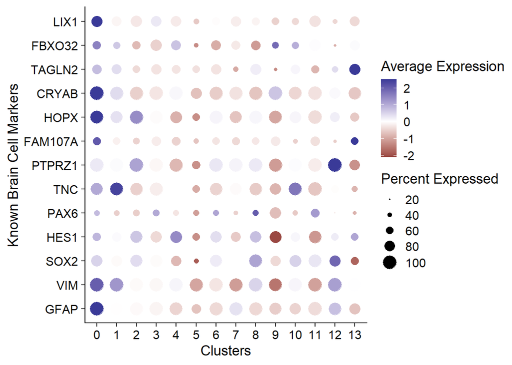

```r
p
```

```r
# ggsave("fig_gbmscte_gte_dotplot_RG_int.tiff", plot = p, units="in", width=size*1.1, height=size*0.7, dpi=300, compression = 'lzw')
```

```r
# Dotplot for RG, oRG, and vRG
DefaultAssay(gte) <- "integrated"
gte <- SetIdent(gte, value = gte@meta.data$integrated_snn_res.0.4)
features.RG <- c(#"VIM", "SOX2", "SLC1A3", "HES1", "PAX6", "GLI3", "PDGFD", #RG -- from Pollen2015,
                 "GFAP", "VIM", "SOX2", "HES1", "PAX6", #RG (only those present in normalized assay)
                 "TNC", "PTPRZ1", "FAM107A", "HOPX", #oRG -- "LIFR", RPS6 not present, Pollen2015 & Nowakowski2017, respectively.
                 #"DAB1", #oRG + vRG not present Nowakowski2017
                 "CRYAB", "TAGLN2", "FBXO32", "LIX1" #vRG -- PDGFD, PALLD NFATC2 were absent (Pollen2015), and "STMN2", "ELAVL4" were targeting other cell types (oligodendrocyte cluster 8) (Nowakowski2017)
                 )
p <- DotPlot(gte, features = features.RG) +   scale_colour_gradient2() +
      xlab("Known Brain Cell Markers") + ylab("Clusters") + coord_flip()
```

```
## which will replace the existing scale.
```

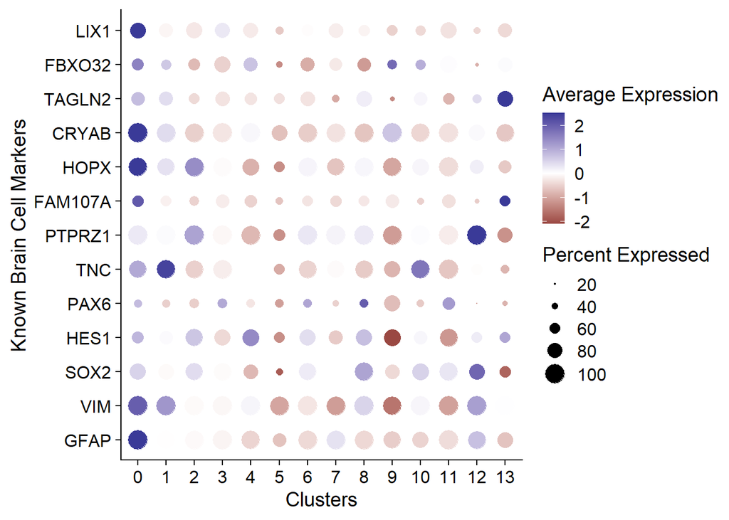

```r
print(p)
```

```r
# ggsave("fig_gbmscte_gte_PC20r04_dotplot_RG_int.tiff", plot = p, units="in", width=size*1.2, height=size*0.7, dpi=300, compression = 'lzw')
```

### UMAP summarizing Cell Types

- isRG: {0: no, 1: yes}
- isoRG: {0:no, 1: oRG}
- isvRG: {0: no, 1: vRG}

```r
#Create updated metadata
DefaultAssay(gte) <- "integrated"
meta <- gte@meta.data

gte_celltype <- c(
  '0' = "Astrocyte",
  '1' = "Intermediate",
  '2' = "OPC",
  '3' = "T-cell",
  '4' = "Microglia",
  '5' = "Proliferating",
  '6' = "Diff. Oligodendrocytes",
  '7' = "Intermediate",
  '8' = "Proliferating",
  '9' = "Intermediate",
  '10' = "Endothelial"
)

gte_rg <- c(
  '0' = 1,
  '1' = 0,
  '2' = 0,
  '3' = 0,
  '4' = 0,
  '5' = 0,
  '6' = 0,
  '7' = 0,
  '8' = 1,
  '9' = 0,
  '10' = 0
)

gte_org <- c(
  '0' = 1,
  '1' = 0,
  '2' = 0,
  '3' = 0,
  '4' = 0,
  '5' = 0,
  '6' = 0,
  '7' = 0,
  '8' = 0,
  '9' = 1,
  '10' = 0
)

gte_vrg <- c(
  '0' = 1,
  '1' = 0,
  '2' = 0,
  '3' = 0,
  '4' = 0,
  '5' = 0,
  '6' = 0,
  '7' = 0,
  '8' = 0,
  '9' = 0,
  '10' = 0
)

meta$int03_celltypes <- NA
meta$int03_isRG <- 0
meta$int03_isoRG <- 0
meta$int03_isvRG <- 0

for (i in 1:length(gte_rg)) {
    meta$int03_celltypes[
        which(as.character(meta$integrated_snn_res.0.3) == names(gte_celltype[i]))]  <- gte_celltype[i]
    meta$int03_isRG[
        which(as.character(meta$integrated_snn_res.0.3) == names(gte_rg[i]))]  <- gte_rg[i]
    meta$int03_isoRG[
        which(as.character(meta$integrated_snn_res.0.3) == names(gte_org[i]))]  <- gte_org[i]
    meta$int03_isvRG[
        which(as.character(meta$integrated_snn_res.0.3) == names(gte_vrg[i]))]  <- gte_vrg[i]
}
head(meta)
```

```
##                        orig.ident  nUMI nGene log10GenesPerUMI   mitoRatio
## GBM_AAACCTGCAATTCCTT-1          1 16712  4840        0.8725599 0.005923887
## GBM_AAACCTGCACAGAGGT-1          1  5963  1850        0.8653694 0.046620828
## GBM_AAACCTGGTGTGGCTC-1          1  7866  2355        0.8655554 0.038901602
## GBM_AAACGGGGTCCGAATT-1          1 14361  3262        0.8451595 0.042615417
## GBM_AAACGGGTCGAATGGG-1          1  2803  1201        0.8932366 0.040313949
## GBM_AAAGATGGTCTCAACA-1          1  6865  2756        0.8966905 0.013255645
##                                     cells    sample nCount_RNA nFeature_RNA
## GBM_AAACCTGCAATTCCTT-1 AAACCTGCAATTCCTT-1 SF11232_1      16712         4840
## GBM_AAACCTGCACAGAGGT-1 AAACCTGCACAGAGGT-1 SF11232_1       5963         1850
## GBM_AAACCTGGTGTGGCTC-1 AAACCTGGTGTGGCTC-1 SF11232_1       7866         2355
## GBM_AAACGGGGTCCGAATT-1 AAACGGGGTCCGAATT-1 SF11232_1      14361         3262
## GBM_AAACGGGTCGAATGGG-1 AAACGGGTCGAATGGG-1 SF11232_1       2803         1201
## GBM_AAAGATGGTCTCAACA-1 AAAGATGGTCTCAACA-1 SF11232_1       6865         2756
##                        GBM_integrated_snn_res.0.8 GBM_seurat_clusters
## GBM_AAACCTGCAATTCCTT-1                          3                   3
## GBM_AAACCTGCACAGAGGT-1                          4                   4
## GBM_AAACCTGGTGTGGCTC-1                          0                   0
## GBM_AAACGGGGTCCGAATT-1                          0                   0
## GBM_AAACGGGTCGAATGGG-1                          0                   0
## GBM_AAAGATGGTCTCAACA-1                          8                   8
##                        neuro.ident nCount_integrated nFeature_integrated
## GBM_AAACCTGCAATTCCTT-1        GBM1                 0                   0
## GBM_AAACCTGCACAGAGGT-1        GBM1                 0                   0
## GBM_AAACCTGGTGTGGCTC-1        GBM1                 0                   0
## GBM_AAACGGGGTCCGAATT-1        GBM1                 0                   0
## GBM_AAACGGGTCGAATGGG-1        GBM1                 0                   0
## GBM_AAAGATGGTCTCAACA-1        GBM1                 0                   0
##                        integrated_snn_res.0.7 seurat_clusters MGMTme
## GBM_AAACCTGCAATTCCTT-1                      1               0   TRUE
## GBM_AAACCTGCACAGAGGT-1                      5               5   TRUE
## GBM_AAACCTGGTGTGGCTC-1                      0               1   TRUE
## GBM_AAACGGGGTCCGAATT-1                      0               1   TRUE
## GBM_AAACGGGTCGAATGGG-1                      2               2   TRUE
## GBM_AAAGATGGTCTCAACA-1                      4               3   TRUE
##                        sampleCombined integrated_snn_res.0.2
## GBM_AAACCTGCAATTCCTT-1        SF11232                      1
## GBM_AAACCTGCACAGAGGT-1        SF11232                      4
## GBM_AAACCTGGTGTGGCTC-1        SF11232                      2
## GBM_AAACGGGGTCCGAATT-1        SF11232                      2
```

[output cut: 15 more lines]

```
## GBM_AAAGATGGTCTCAACA-1                      2                      3 24.85069
##                                  gbm_subtype int03_celltypes int03_isRG
## GBM_AAACCTGCAATTCCTT-1 Classical-Mesenchymal    Intermediate          0
## GBM_AAACCTGCACAGAGGT-1           Mesenchymal       Microglia          0
## GBM_AAACCTGGTGTGGCTC-1             Classical       Astrocyte          1
## GBM_AAACGGGGTCCGAATT-1             Classical       Astrocyte          1
## GBM_AAACGGGTCGAATGGG-1   Classical-Proneural             OPC          0
## GBM_AAAGATGGTCTCAACA-1   Classical-Proneural             OPC          0
##                        int03_isoRG int03_isvRG
## GBM_AAACCTGCAATTCCTT-1           0           0
## GBM_AAACCTGCACAGAGGT-1           0           0
## GBM_AAACCTGGTGTGGCTC-1           1           1
## GBM_AAACGGGGTCCGAATT-1           1           1
## GBM_AAACGGGTCGAATGGG-1           0           0
## GBM_AAAGATGGTCTCAACA-1           0           0
```

```r
gte@meta.data <- meta
# saveRDS(gte, file="gte_celltypes.rds")
# write.csv(meta,"gbmscte_meta_celltypes.csv", row.names= TRUE)
```

Create UMAP

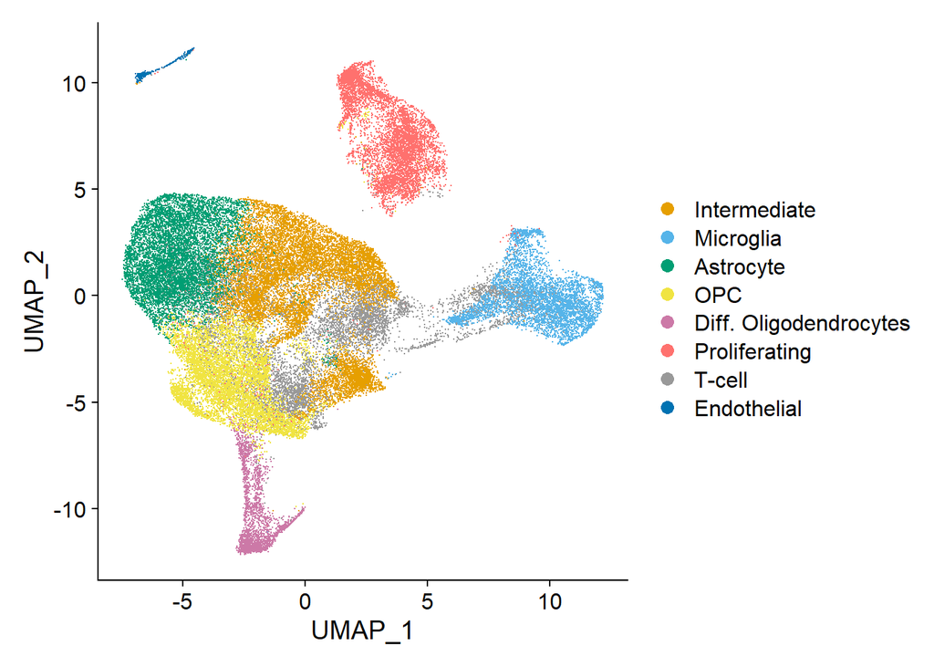

```r
cbPalette <- c("#E69F00", "#56B4E9", "#009E73", "#F0E442",
               "#CC79A7", "#ff716e", "#999999", "#0072B2",
               "#194c76", "#D55E00", "#4C4E52")
gte <- SetIdent(gte, value = gte@meta.data$int03_celltypes)
p <- DimPlot(gte, label=FALSE, cols = cbPalette)
p
```

```r
# ggsave("fig_gbmscte_gte_PC20r03_UMAP_celltypes.tiff", plot = p, units="in", width=size*1.4, height=size*1, dpi=300, compression = 'lzw')
```

### Dot plot Summarizing known markers by cell type

```r
DefaultAssay(gte) <- "integrated"
meta$int03_celltypes <- factor(meta$int03_celltypes,
                                       levels = c(
                                         "Astrocyte",
                                         "OPC",
                                         "Diff. Oligodendrocytes",
                                         "Microglia",
                                         "Proliferating",
                                         "Endothelial",
                                         "T-cell",
                                         "Intermediate"
                                       ))
gte@meta.data <- meta
gte <- SetIdent(gte, value = gte@meta.data$int03_celltypes)
features <- c(#"HBB", #Blood
              "CD3E", #"CD8A", #T-cells
              "FLT1", "VWF", "FN1", #Endothelial
              #"ASCL1", # IPC-late (?)
              #"PVALB", "SST", "GAD1", # Differentiated Cortical Interneurons (Inhibitory neurons)
              "MKI67", "MCM6", "TOP2A", "PCNA",  #Proliferating Cell Type
              "PTPRC", "C1QC", "CD68", "TREM2", "GPR34", "CSF1R", "CX3CR1", #Microglia,
                #"P2RY12", "HEXB" were absent
              "MYRF", "MBP", "MOG", "PLP1", #Oligodendrocytes
              "OLIG1", "OLIG2", "PDGFRA", "SOX10",  #OPC, "COL20A1" was absent
              "GFAP", "AQP4", "HOPX", "SLC1A2" #Astrocytes
              #"HES1" #NPC
             )

p <- DotPlot(gte, features = features) +   scale_colour_gradient2() +
      xlab("Known Brain Cell Markers") + ylab("Cell Types") + coord_flip() +
      theme(axis.text.x = element_text(angle = 40, vjust = 1, hjust=1))
```

```
## which will replace the existing scale.
```

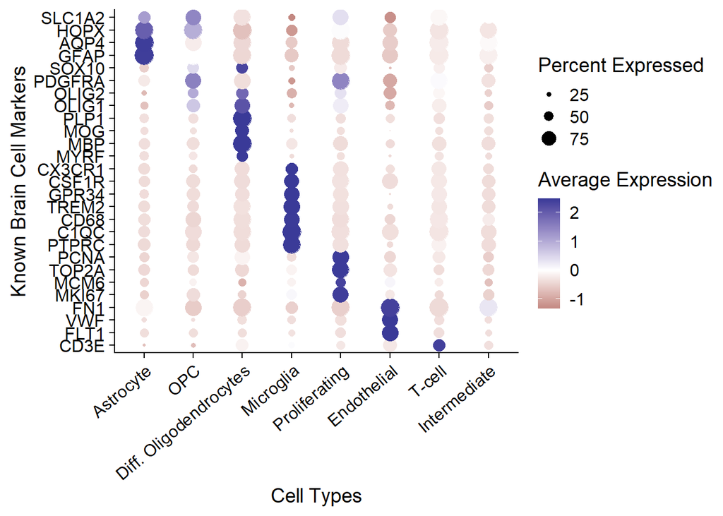

```r
p
```

```r
# ggsave("fig_gbmscte_gte_dotplot_summary_int_celltypes.tiff", plot = p, units="in", width=size*1.1, height=size*1.3, dpi=300, compression = 'lzw')
```

### Unload data

```r
rm(gte)
gc()
```

```
##             used   (Mb) gc trigger   (Mb)  max used   (Mb)
## Ncells   3561761  190.3    6227361  332.6   6227361  332.6
## Vcells 590205135 4503.0  998984105 7621.7 644790946 4919.4
```

## PLot Known Cell Type Markers:GE

### Load data

```r
ge <- readRDS("D:\\backup files\\2021-11-11\\Cluster\\scratch\\gete-gbm\\results\\GBM-GSC neuroblastoma TE\\2021-09-02\\ge_gbmscIntUmap-subtypes.rds")

# DefaultAssay(ge) <- "integrated"
Idents(ge) <- "integrated_snn_res.0.3"
DefaultAssay(ge) <- "RNA"
size = 5

colnames(ge@meta.data)
```

```
##  [1] "orig.ident"                 "nUMI"
##  [3] "nGene"                      "log10GenesPerUMI"
##  [5] "mitoRatio"                  "cells"
##  [7] "sample"                     "nCount_RNA"
##  [9] "nFeature_RNA"               "GBM_integrated_snn_res.0.8"
## [11] "GBM_seurat_clusters"        "neuro.ident"
## [13] "nCount_integrated"          "nFeature_integrated"
## [15] "integrated_snn_res.0.7"     "seurat_clusters"
## [17] "MGMTme"                     "sampleCombined"
## [19] "integrated_snn_res.0.2"     "integrated_snn_res.0.3"
## [21] "integrated_snn_res.0.4"     "integrated_snn_res.0.5"
## [23] "integrated_snn_res.0.6"     "gbm_subtype"
```

```r
setwd("D:\\backup files\\getegbm\\gete-gbm\\results\\GBM-GSC neuroblastoma TE\\2022-11-09_celltypes_gbmsc")
  #run this line outside of a chunk
```

### UMAPs

Known Cell types markers from Velmeshev2019, Zhong 2018, Nowakowski2017, and discussions with Dr. Tanaka (Aug 2021)

```r
## Neural Progenitor Cells (NPCs) Early Development Markers
print(match(c("PAX6", "SOX2"), rownames(ge)))
```

```
## [1] 16734  6621
```

```r
p <- FeaturePlot(ge, features = c("PAX6", "SOX2"))
# ggsave("fig_gbmscte_ge_NPC-early.tiff", plot = p, units="in", width=size*2, height=size*2, dpi=300, compression = 'lzw')
```

```r
## NPCs Late Marker Genes
print(match(c("SFRP1", "RBFOX1", "HES1", "SOX2", "EMX2", "EOMES"), rownames(ge)))
```

```
## [1] 13097 22798  6761  6621 16143  5355
```

```r
p <- FeaturePlot(ge, features = c("SFRP1", "RBFOX1", "HES1", "SOX2", "EMX2", "EOMES"))
# ggsave("fig_gbmscte_ge_NPC-late_RNA.tiff", plot = p, units="in", width=size*2, height=size*3, dpi=300, compression = 'lzw')
```

```r
## Excitatory Neurons Early Markers
print(match(c("NEUROD2"), rownames(ge)))
```

```
## [1] 24772
```

```r
p <- FeaturePlot(ge, features = c("NEUROD2"))
# ggsave("fig_gbmscte_ge_ExcN-early_RNA.tiff", plot = p, units="in", width=size, height=size, dpi=300, compression = 'lzw')
```

```r
## Excitatory Neurons Late Markers
print(match(c("NEUROD1", "NEUROD6", "SFRP1", "SLA", "NEUROD2", "HES1"), rownames(ge)))
```

```
## [1]  4542 11570 13097 13783 24772  6761
```

```r
p <- FeaturePlot(ge, features = c("NEUROD1", "NEUROD6", "SFRP1", "SLA", "NEUROD2", "HES1"))
# ggsave("fig_gbmscte_ge_ExcN-late_RNA.tiff", plot = p, units="in", width=size*2, height=size*3, dpi=300, compression = 'lzw')
```

```r
## Interneurons Early Markers
print(match(c("TTF1", "LHX6", "DLX1", "DLX2", "CALB2", "SST"), rownames(ge)))
```

```
## [1] 14941 14746  4440  4441 23638  6717
```

```r
p <- FeaturePlot(ge, features = c("TTF1", "LHX6", "DLX1", "DLX2", "CALB2", "SST"))
# ggsave("fig_gbmscte_ge_InterN-early.tiff", plot = p, units="in", width=size*2, height=size*3, dpi=300, compression = 'lzw')
```

```r
## Interneurons Late Markers
print(match(c("GAD1", "GAD2", "PDE4DIP", "LHX6", "DLX1", "CALB2", "CCK", "VIP", "PVALB"), rownames(ge)))
```

```
## [1]  4427 15337  1673 14746  4440 23638  5463 11053 29907
```

```r
p <- FeaturePlot(ge, features = c("GAD1", "GAD2", "PDE4DIP", "LHX6", "DLX1", "CALB2", "CCK", "VIP", "PVALB"))
# ggsave("fig_gbmscte_ge_InterN-late.tiff", plot = p, units="in", width=size*2, height=size*2, dpi=300, compression = 'lzw')
```

```r
## OPC Markers
print(match(c("OLIG1", "OLIG2", "SOX10", "SOX2", "YY1", "ZNF24", "ASCL1", "PDGFRA", "HES5", "COL20A1", "PMP2"), rownames(ge)))
```

```
##  [1] 29232 29230 29946  6621 21262 26029 19267  7248    98 29015 13409
```

```r
p <- FeaturePlot(ge, features = c("OLIG1", "OLIG2", "SOX10", "SOX2", "YY1", "ZNF24", "ASCL1", "PDGFRA", "HES5", "COL20A1", "PMP2"))
# ggsave("fig_gbmscte_ge_OPC_RNA.tiff", plot = p, units="in", width=size*4, height=size*3, dpi=300, compression = 'lzw')
```

```r
## Oligodendrocytes
print(match(c("MYRF","MBP", "MOG", "PLP1"), rownames(ge)))
```

```
## [1] 17017 26328  9999 30816
```

```r
p <- FeaturePlot(ge, features = c("MYRF","MBP", "MOG", "PLP1"))
# ggsave("fig_gbmscte_ge_OLIG_RNA.tiff", plot = p, units="in", width=size*2, height=size*2, dpi=300, compression = 'lzw')
```

```r
## Astrocytes
print(match(c("GFAP", "AQP4", "SLCO1C1", "SLC1A2"), rownames(ge)))
```

```
## [1] 24971 25970 18361 16775
```

```r
p <- FeaturePlot(ge, features = c("GFAP", "AQP4", "SLCO1C1", "SLC1A2"))
# ggsave("fig_gbmscte_ge_Ast_RNA.tiff", plot = p, units="in", width=size*2, height=size*2, dpi=300, compression = 'lzw')
```

```r
## Microglia early + late development
print(match(c("P2RY12", "PTPRC", "C1QB", "CD68", "TREM2", "GPR34", "CSF1R", "CXCR1"), rownames(ge)))
```

```
## [1]  6417  2380   421 24208 10285 30440  9295  4834
```

```r
p <- FeaturePlot(ge, features = c("P2RY12", "PTPRC", "C1QB", "CD68", "TREM2", "GPR34", "CSF1R", "CXCR1"))
# ggsave("fig_gbmscte_ge_MGlia_earlylate_RNA.tiff", plot = p, units="in", width=size*3, height=size*3, dpi=300, compression = 'lzw')
```

```r
## Outer Radial Glia- early-late
print(match(c("HOPX", "FAM107A", "TNC", "PAX6", "VIM", "ZIC2", "SLC7A11", "MTOR", "DAB1","LAMP5", "IL13RA2"), rownames(ge)))
```

```
##  [1]  7278  5776 14704 16734 15268 20212  7748   236  1034 28382 30875
```

```r
p <- FeaturePlot(ge, features = c("HOPX", "FAM107A", "TNC", "PAX6", "VIM", "ZIC2", "SLC7A11", "MTOR", "DAB1","LAMP5", "IL13RA2"))
# ggsave("fig_gbmscte_ge_oRG_RNA.tiff", plot = p, units="in", width=size*4, height=size*3, dpi=300, compression = 'lzw')
```

```r
## Ventral Radial glia Progenitor cells
print(match(c("DLX1", "DLX2", "FLRT2", "LIX1"), rownames(ge)))
```

```
## [1]  4440  4441 21102  8787
```

```r
p <- FeaturePlot(ge, features = c("DLX1", "DLX2", "FLRT2", "LIX1"))
# ggsave("fig_gbmscte_ge_vRGprogenitor_RNA.tiff", plot = p, units="in", width=size*2, height=size*2, dpi=300, compression = 'lzw')
```

```r
## Cortical ventral radial glia
print(match(c("PAX6", "VIM", "ZIC2", "HOPX"), rownames(ge)))
```

```
## [1] 16734 15268 20212  7278
```

```r
p <- FeaturePlot(ge, features = c("PAX6", "VIM", "ZIC2", "HOPX"))
# ggsave("fig_gbmscte_ge_vRG_RNA.tiff", plot = p, units="in", width=size*2, height=size*2, dpi=300, compression = 'lzw')
```

```r
## IPC (Intermediate precursor cells) - early
print(match(c("NHLH1", "SLC1A3"), rownames(ge)))
```

```
## [1] 2015 8331
```

```r
p <- FeaturePlot(ge, features = c("NHLH1", "SLC1A3"))
# ggsave("fig_gbmscte_ge_IPC_early_RNA.tiff", plot = p, units="in", width=size*2, height=size, dpi=300, compression = 'lzw')
```

```r
## IPC (Intermediate precursor cells) - late
print(match(c("ASCL1", "NHLH2", "TP53I11", "PPP1R17", "ADRA2A", "LTBP1"), rownames(ge)))
```

```
## [1] 19267  1543 16828 11572 16087  3326
```

```r
p <- FeaturePlot(ge, features = c("ASCL1", "NHLH2", "TP53I11", "PPP1R17", "ADRA2A", "LTBP1"))
# ggsave("fig_gbmscte_ge_IPC_late_RNA.tiff", plot = p, units="in", width=size*2, height=size*6, dpi=300, compression = 'lzw')
```

```r
## Ventral IPC (Intermediate precursor cells)
print(match(c("FLRT2", "DLX1", "DLX2", "DLX5", "DLX6"), rownames(ge)))
```

```
## [1] 21102  4440  4441 12017 12016
```

```r
p <- FeaturePlot(ge, features = c("FLRT2", "DLX1", "DLX2", "DLX5", "DLX6"))
# ggsave("fig_gbmscte_ge_ventralIPC_RNA.tiff", plot = p, units="in", width=size*2, height=size*3, dpi=300, compression = 'lzw')
```

```r
## dorsal IPC (Intermediate precursor cells)
print(match(c("PAX6", "ZIC2", "EOMES", "ASCL1", "SSTR2"), rownames(ge)))
```

```
## [1] 16734 20212  5355 19267 25403
```

```r
p <- FeaturePlot(ge, features = c("PAX6", "ZIC2", "EOMES", "ASCL1", "SSTR2"))
# ggsave("fig_gbmscte_ge_dorsalIPC_RNA.tiff", plot = p, units="in", width=size*2, height=size*3, dpi=300, compression = 'lzw')
```

```r
## Endothelial Cells
print(match(c("FLT1", "VWF", "FN1"), rownames(ge)))
```

```
## [1] 19807 18105  4799
```

```r
p <- FeaturePlot(ge, features = c("FLT1", "VWF", "FN1"))
# ggsave("fig_gbmscte_ge_Endothelial_RNA.tiff", plot = p, units="in", width=size*2, height=size*2, dpi=300, compression = 'lzw')
```

```r
## T-cells
print(match(c("CD3E", "CD8A"), rownames(ge)))
```

```
## [1] 17780  3807
```

```r
p <- FeaturePlot(ge, features = c("CD3E", "CD8A"))
# ggsave("fig_gbmscte_ge_Tcells_RNA.tiff", plot = p, units="in", width=size*2, height=size, dpi=300, compression = 'lzw')
```

```r
## Blood Cells
print(match(c("HBB"), rownames(ge)))
```

```
## [1] 16462
```

```r
p <- FeaturePlot(ge, features = c("HBB"))
# ggsave("fig_gbmscte_ge_Blood_RNA.tiff", plot = p, units="in", width=size, height=size, dpi=300, compression = 'lzw')
```

### Summary Dot plot

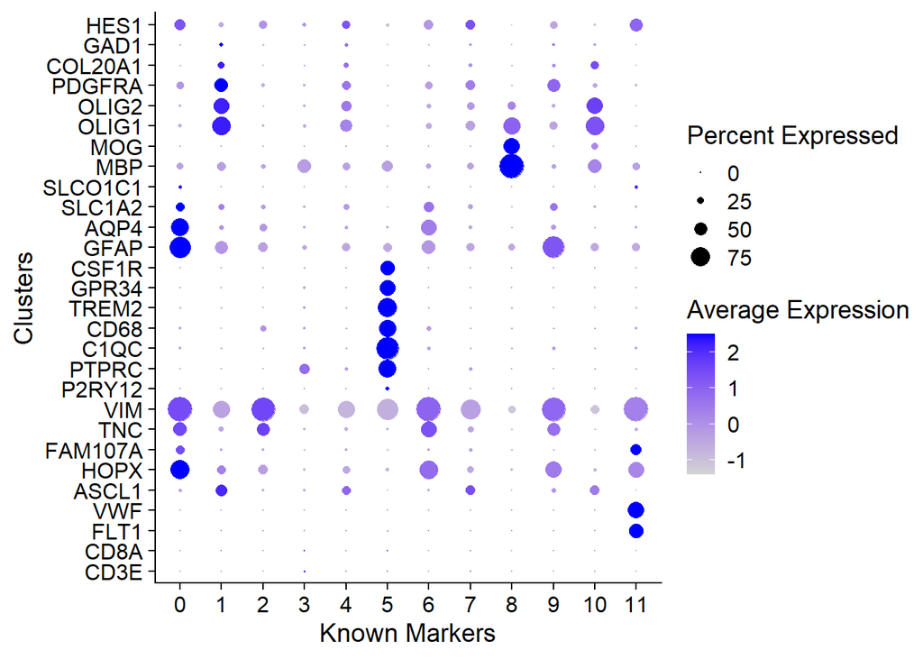

```r
DefaultAssay(ge) <- "RNA"
features = c("CD3E", "CD8A", #T-cells
             "FLT1", "VWF", #Endothelial
             "ASCL1", # IPC-late (?)
             "HOPX", "FAM107A", "TNC", "VIM", #orG
              "P2RY12", "PTPRC", "C1QC", "CD68", "TREM2", "GPR34", "CSF1R", #Microglia
              "GFAP", "AQP4",  "SLC1A2", "SLCO1C1", #Astrocytes
              "MBP", "MOG", #Oligodendrocytes
              "OLIG1", "OLIG2", "PDGFRA", "COL20A1", #OPC
              "GAD1", #Interneurons
              "HES1" #NPC
             )

p <- DotPlot(ge, features = features) +
      xlab("Clusters") + ylab("Known Markers") + coord_flip()
p
```

```r
# ggsave("fig_gbmscte_ge_dotplot_summary.tiff", plot = p, units="in", width=size*1.4, height=size*1.1, dpi=300, compression = 'lzw')
```

```r
DefaultAssay(ge) <- "integrated"
features <- c(#"HBB", #Blood
              "CD3E", #"CD8A", #T-cells
              "FLT1", "VWF", "FN1", #Endothelial
              #"ASCL1", # IPC-late (?)
              #"PVALB", "SST", "GAD1", # Differentiated Cortical Interneurons (Inhibitory neurons)
              "MKI67", "MCM6", "TOP2A", "PCNA",  #Proliferating Cell Type
              "PTPRC", "C1QC", "CD68", "TREM2", "GPR34", "CSF1R", "CX3CR1", #Microglia,
                #"P2RY12", "HEXB" were absent
              "GFAP", "AQP4", "HOPX", "SLC1A2", #Astrocytes
              "MYRF", "MBP", "MOG", "PLP1", #Oligodendrocytes
              "OLIG1", "OLIG2", "PDGFRA", "SOX10"  #OPC, "COL20A1" was absent
              #"HES1" #NPC
             )

p <- DotPlot(ge, features = features) + scale_colour_gradient2() +
      xlab("Clusters") + ylab("Known Markers") + coord_flip()
```

```
## which will replace the existing scale.
```

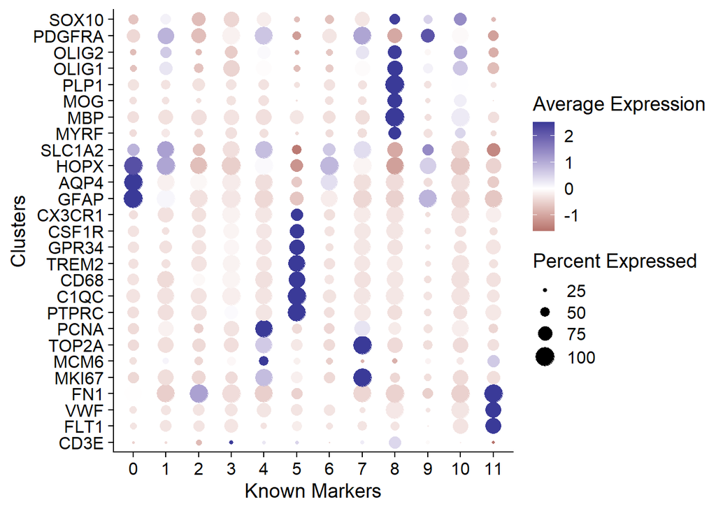

```r
p
```

```r
# ggsave("fig_gbmscte_ge_dotplot_summary.tiff", plot = p, units="in", width=size*1.4, height=size*1.1, dpi=300, compression = 'lzw')
```

```r
# Dotplot for RG, oRG, and vRG
DefaultAssay(ge) <- "integrated"
features.RG <- c(#"VIM", "SOX2", "SLC1A3", "HES1", "PAX6", "GLI3", "PDGFD", #RG -- from Pollen2015,
                 "GFAP", "VIM", "HES1", "PAX6", #RG (only those present in normalized assay)
                 "TNC", "PTPRZ1", "FAM107A", "HOPX", #oRG -- "LIFR", RPS6 not present, Pollen2015 & Nowakowski2017, respectively.
                 # "DAB1", #oRG + vRG not present Nowakowski2017
                 "CRYAB", "TAGLN2", "FBXO32", "LIX1", "ZIC2"#vRG -- PDGFD, PALLD NFATC2 were absent (Pollen2015), and "STMN2", "ELAVL4" were targeting other cell types (oligodendrocyte cluster 8) (Nowakowski2017)
                 )
p <- DotPlot(ge, features = features.RG) +   scale_colour_gradient2() +
      xlab("Known Brain Cell Markers") + ylab("Clusters") + coord_flip()
```

```
## which will replace the existing scale.
```

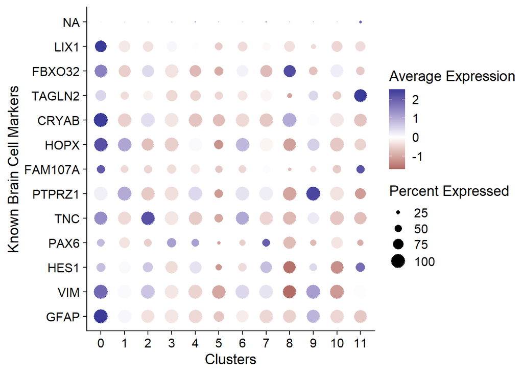

```r
p
```

```r
# ggsave("fig_gbmscte_ge_dotplot_RG_int.tiff", plot = p, units="in", width=size*1.3, height=size*0.7, dpi=300, compression = 'lzw')
```

Repeat for other PCA resolutions

```r
#Dotplot for PC20r0.4
DefaultAssay(ge) <- "integrated"
print(head(ge@active.ident))
```

```
## GBM_AAACCTGCAATTCCTT-1 GBM_AAACCTGCACAGAGGT-1 GBM_AAACCTGGTGTGGCTC-1
##                      2                      5                      0
## GBM_AAACGGGGTCCGAATT-1 GBM_AAACGGGTCGAATGGG-1 GBM_AAAGATGGTCTCAACA-1
##                      0                      0                      0
## Levels: 0 1 2 3 4 5 6 7 8 9 10 11
```

```r
ge <- SetIdent(ge, value = ge@meta.data$integrated_snn_res.0.4)
print(head(ge@active.ident))
```

```
## GBM_AAACCTGCAATTCCTT-1 GBM_AAACCTGCACAGAGGT-1 GBM_AAACCTGGTGTGGCTC-1
##                      1                      3                      0
## GBM_AAACGGGGTCCGAATT-1 GBM_AAACGGGTCGAATGGG-1 GBM_AAAGATGGTCTCAACA-1
##                      0                      0                      0
## Levels: 0 1 2 3 4 5 6 7 8 9 10 11 12 13 14
```

```r
features <- c(#"HBB", #Blood
              "CD3E", #"CD8A", #T-cells
              "FLT1", "VWF", "FN1", #Endothelial
              #"ASCL1", # IPC-late (?)
              #"PVALB", "SST", "GAD1", # Differentiated Cortical Interneurons (Inhibitory neurons)
              "MKI67", "MCM6", "TOP2A", "PCNA",  #Proliferating Cell Type
              "PTPRC", "C1QC", "CD68", "TREM2", "GPR34", "CSF1R", "CX3CR1", #Microglia,
                #"P2RY12", "HEXB" were absent
              "GFAP", "AQP4", "HOPX", "SLC1A2", #Astrocytes
              "MYRF", "MBP", "MOG", "PLP1", #Oligodendrocytes
              "OLIG1", "OLIG2", "PDGFRA", "SOX10"  #OPC, "COL20A1" was absent
              #"HES1" #NPC
             )

p <- DotPlot(ge, features = features) +   scale_colour_gradient2() +
      xlab("Known Brain Cell Markers") + ylab("Clusters") + coord_flip()
```

```
## which will replace the existing scale.
```

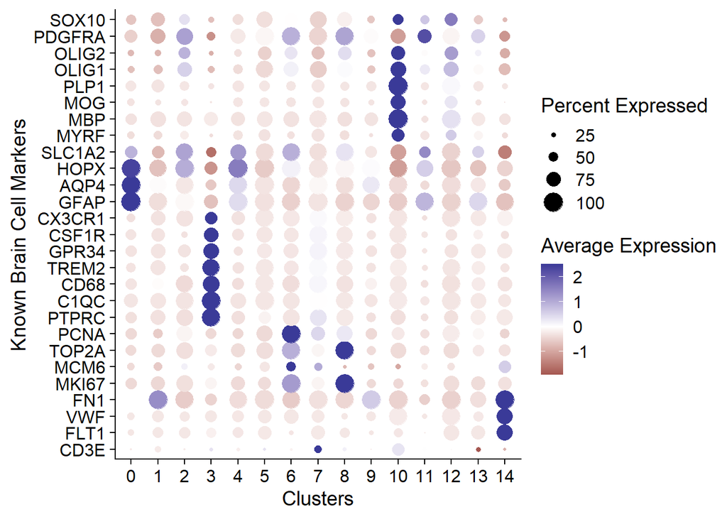

```r
print(p)
```

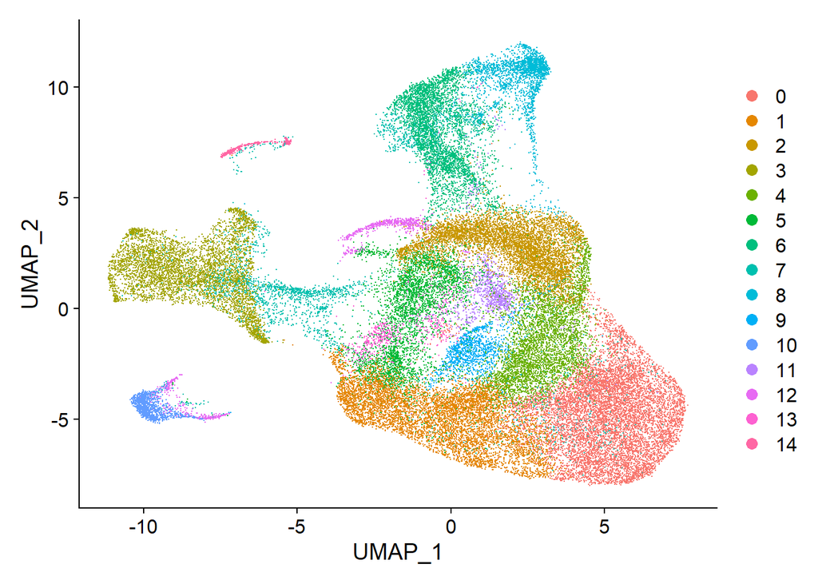

```r
# ggsave("fig_gbmscte_ge_PC20r04_dotplot_summary_int.tiff", plot = p, units="in", width=size*1.1, height=size*1.2, dpi=300, compression = 'lzw')

p <- UMAPPlot(ge)
print(p)
```

```r
# ggsave("fig_gbmscte_ge_PC20r04_UMAP.tiff", plot = p, units="in", width=size*1.2, height=size*1, dpi=300, compression = 'lzw')
```

```r
# Dotplot for RG, oRG, and vRG
DefaultAssay(ge) <- "integrated"
ge <- SetIdent(ge, value = ge@meta.data$integrated_snn_res.0.4)
features.RG <- c(#"VIM", "SOX2", "SLC1A3", "HES1", "PAX6", "GLI3", "PDGFD", #RG -- from Pollen2015,
                 "GFAP", "VIM", "HES1", "PAX6", #RG (only those present in normalized assay)
                 "TNC", "PTPRZ1", "FAM107A", "HOPX", #oRG -- "LIFR", RPS6 not present, Pollen2015 & Nowakowski2017, respectively.
                 # "DAB1", #oRG + vRG not present Nowakowski2017
                 "CRYAB", "TAGLN2", "FBXO32", "LIX1"#vRG -- PDGFD, PALLD NFATC2 were absent (Pollen2015), and "STMN2", "ELAVL4" were targeting other cell types (oligodendrocyte cluster 8) (Nowakowski2017), ZIC2 was also absent
                 )
p <- DotPlot(ge, features = features.RG) +   scale_colour_gradient2() +
      xlab("Known Brain Cell Markers") + ylab("Clusters") + coord_flip()
```

```
## which will replace the existing scale.
```

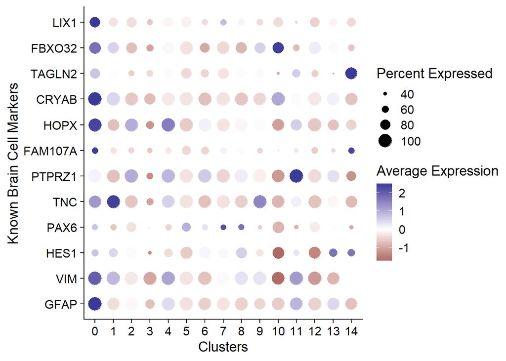

```r
p
```

```r
# ggsave("fig_gbmscte_ge_PCr04_dotplot_RG_int.tiff", plot = p, units="in", width=size*1.3, height=size*0.7, dpi=300, compression = 'lzw')
```

### Update Metadata

- isRG: {0: no, 1: yes}
- isoRG: {0:no, 1: oRG}
- isvRG: {0: no, 1: vRG}

```r
#Create updated metadata
DefaultAssay(ge) <- "integrated"
meta <- ge@meta.data

ge_celltype <- c(
  '0' = "Astrocyte",
  '1' = "OPC",
  '2' = "Intermediate",
  '3' = "T-cell",
  '4' = "Proliferating",
  '5' = "Microglia",
  '6' = "Astrocyte",
  '7' = "Proliferating",
  '8' = "Diff. Oligodendrocytes",
  '9' = "Astrocyte",
  '10' = "Diff. Oligodendrocytes",
  '11' = "Endothelial"
)

ge_rg <- c(
  '0' = 1,
  '1' = 0,
  '2' = 0,
  '3' = 0,
  '4' = 0,
  '5' = 0,
  '6' = 0,
  '7' = 1,
  '8' = 0,
  '9' = 1,
  '10' = 0,
  '11' = 0
)

ge_org <- c(
  '0' = 1,
  '1' = 0,
  '2' = 0,
  '3' = 0,
  '4' = 0,
  '5' = 0,
  '6' = 1,
  '7' = 0,
  '8' = 0,
  '9' = 1,
  '10' = 0,
  '11' = 0
)

ge_vrg <- c(
  '0' = 1,
  '1' = 0,
  '2' = 0,
  '3' = 0,
  '4' = 0,
  '5' = 0,
  '6' = 0,
  '7' = 0,
  '8' = 0,
  '9' = 0,
  '10' = 0,
  '11' = 0
)

meta$int03_celltypes <- NA
meta$int03_isRG <- 0
meta$int03_isoRG <- 0
meta$int03_isvRG <- 0

for (i in 1:length(ge_rg)) {
    meta$int03_celltypes[
        which(as.character(meta$integrated_snn_res.0.3) == names(ge_celltype[i]))]  <- ge_celltype[i]
    meta$int03_isRG[
        which(as.character(meta$integrated_snn_res.0.3) == names(ge_rg[i]))]  <- ge_rg[i]
    meta$int03_isoRG[
        which(as.character(meta$integrated_snn_res.0.3) == names(ge_org[i]))]  <- ge_org[i]
    meta$int03_isvRG[
        which(as.character(meta$integrated_snn_res.0.3) == names(ge_vrg[i]))]  <- ge_vrg[i]
}
head(meta)
```

```
##                        orig.ident  nUMI nGene log10GenesPerUMI   mitoRatio
## GBM_AAACCTGCAATTCCTT-1          1 11916  4509        0.8964581 0.008308157
## GBM_AAACCTGCACAGAGGT-1          1  4061  1671        0.8931295 0.068456045
## GBM_AAACCTGGTGTGGCTC-1          1  4314  2102        0.9140969 0.070931850
## GBM_AAACGGGGTCCGAATT-1          1  7251  2943        0.8985577 0.084402151
## GBM_AAACGGGTCGAATGGG-1          1  1708  1049        0.9345048 0.066159251
## GBM_AAAGATGGTCTCAACA-1          1  5158  2538        0.9170394 0.017642497
##                                     cells    sample nCount_RNA nFeature_RNA
## GBM_AAACCTGCAATTCCTT-1 AAACCTGCAATTCCTT-1 SF11159_2      11916         4509
## GBM_AAACCTGCACAGAGGT-1 AAACCTGCACAGAGGT-1 SF11159_2       4061         1671
## GBM_AAACCTGGTGTGGCTC-1 AAACCTGGTGTGGCTC-1 SF11159_2       4314         2102
## GBM_AAACGGGGTCCGAATT-1 AAACGGGGTCCGAATT-1 SF11159_2       7251         2943
## GBM_AAACGGGTCGAATGGG-1 AAACGGGTCGAATGGG-1 SF11159_2       1708         1049
## GBM_AAAGATGGTCTCAACA-1 AAAGATGGTCTCAACA-1 SF11159_2       5158         2538
##                        GBM_integrated_snn_res.0.8 GBM_seurat_clusters
## GBM_AAACCTGCAATTCCTT-1                          7                   7
## GBM_AAACCTGCACAGAGGT-1                          3                   3
## GBM_AAACCTGGTGTGGCTC-1                          0                   0
## GBM_AAACGGGGTCCGAATT-1                          0                   0
## GBM_AAACGGGTCGAATGGG-1                          0                   0
## GBM_AAAGATGGTCTCAACA-1                         14                  14
##                        neuro.ident nCount_integrated nFeature_integrated
## GBM_AAACCTGCAATTCCTT-1        GBM1                 0                   0
## GBM_AAACCTGCACAGAGGT-1        GBM1                 0                   0
## GBM_AAACCTGGTGTGGCTC-1        GBM1                 0                   0
## GBM_AAACGGGGTCCGAATT-1        GBM1                 0                   0
## GBM_AAACGGGTCGAATGGG-1        GBM1                 0                   0
## GBM_AAAGATGGTCTCAACA-1        GBM1                 0                   0
##                        integrated_snn_res.0.7 seurat_clusters MGMTme
## GBM_AAACCTGCAATTCCTT-1                      1               3   TRUE
## GBM_AAACCTGCACAGAGGT-1                      8               4   TRUE
## GBM_AAACCTGGTGTGGCTC-1                      0               0   TRUE
## GBM_AAACGGGGTCCGAATT-1                      0               6   TRUE
## GBM_AAACGGGTCGAATGGG-1                      0               0   TRUE
## GBM_AAAGATGGTCTCAACA-1                      0               0   TRUE
##                        sampleCombined integrated_snn_res.0.2
## GBM_AAACCTGCAATTCCTT-1        SF11159                      2
## GBM_AAACCTGCACAGAGGT-1        SF11159                      5
## GBM_AAACCTGGTGTGGCTC-1        SF11159                      0
## GBM_AAACGGGGTCCGAATT-1        SF11159                      0
```

[output cut: 15 more lines]

```
## GBM_AAAGATGGTCTCAACA-1                      7                      0
##                                  gbm_subtype int03_celltypes int03_isRG
## GBM_AAACCTGCAATTCCTT-1 Classical-Mesenchymal    Intermediate          0
## GBM_AAACCTGCACAGAGGT-1           Mesenchymal       Microglia          0
## GBM_AAACCTGGTGTGGCTC-1             Classical       Astrocyte          1
## GBM_AAACGGGGTCCGAATT-1             Classical       Astrocyte          1
## GBM_AAACGGGTCGAATGGG-1             Classical       Astrocyte          1
## GBM_AAAGATGGTCTCAACA-1             Classical       Astrocyte          1
##                        int03_isoRG int03_isvRG
## GBM_AAACCTGCAATTCCTT-1           0           0
## GBM_AAACCTGCACAGAGGT-1           0           0
## GBM_AAACCTGGTGTGGCTC-1           1           1
## GBM_AAACGGGGTCCGAATT-1           1           1
## GBM_AAACGGGTCGAATGGG-1           1           1
## GBM_AAAGATGGTCTCAACA-1           1           1
```

```r
ge@meta.data <- meta
# saveRDS(ge, file="ge_celltypes.rds")
# write.csv(meta,"gbmsc_meta_celltypes.csv", row.names= TRUE)
```

Create UMAP

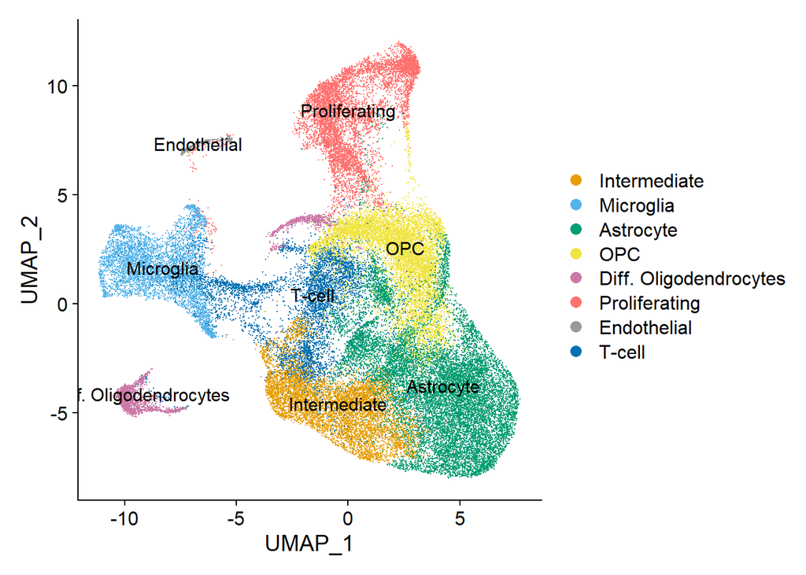

```r
cbPalette <- c("#E69F00", "#56B4E9", "#009E73", "#F0E442",
               "#CC79A7", "#ff716e", "#999999", "#0072B2",
               "#194c76", "#D55E00", "#4C4E52")
ge <- SetIdent(ge, value = ge@meta.data$int03_celltypes)
p <- DimPlot(ge, label=TRUE, cols = cbPalette)
p
```

```r
# ggsave("fig_gbmscte_ge_PC20r03_UMAP_celltypes_labels.tiff", plot = p, units="in", width=size*1.4, height=size*1, dpi=300, compression = 'lzw')
```

Repeat Metadata for PC20r04 clusters

```r
#Create updated metadata
DefaultAssay(ge) <- "integrated"
meta <- ge@meta.data

ge_celltype <- c(
  '0' = "Astrocyte",
  '1' = "Intermediate",
  '2' = "OPC",
  '3' = "Microglia",
  '4' = "Astrocyte",
  '5' = "Intermediate",
  '6' = "Proliferating",
  '7' = "T-cell",
  '8' = "Proliferating",
  '9' = "Intermediate",
  '10' = "Diff. Oligodendrocyte",
  '11' = "Intermediate",
  '12' = "OPC",
  '13' = "Intermediate",
  '14' = "Endothelial"
)

ge_rg <- c(
  '0' = 1,
  '1' = 0,
  '2' = 0,
  '3' = 0,
  '4' = 0,
  '5' = 0,
  '6' = 0,
  '7' = 0,
  '8' = 1,
  '9' = 0,
  '10' = 0,
  '11' = 1,
  '12' = 0,
  '13' = 0,
  '14' = 0
)

ge_org <- c(
  '1' = 1,
  '2' = 0,
  '3' = 0,
  '4' = 1,
  '5' = 0,
  '6' = 0,
  '7' = 0,
  '8' = 0,
  '9' = 0,
  '10' = 0,
  '11' = 1,
  '12' = 0,
  '13' = 0,
  '14' = 0
)

ge_vrg <- c(
  '1' = 1,
  '2' = 0,
  '3' = 0,
  '4' = 0,
  '5' = 0,
  '6' = 0,
  '7' = 0,
  '8' = 0,
  '9' = 0,
  '10' = 0,
  '11' = 0,
  '12' = 0,
  '13' = 0,
  '14' = 0
)

meta$int04_celltypes <- NA
meta$int04_isRG <- 0
meta$int04_isoRG <- 0
meta$int04_isvRG <- 0

for (i in 1:length(ge_rg)) {
    meta$int04_celltypes[
        which(as.character(meta$integrated_snn_res.0.4) == names(ge_celltype[i]))]  <- ge_celltype[i]
    meta$int04_isRG[
        which(as.character(meta$integrated_snn_res.0.4) == names(ge_rg[i]))]  <- ge_rg[i]
    meta$int04_isoRG[
        which(as.character(meta$integrated_snn_res.0.4) == names(ge_org[i]))]  <- ge_org[i]
    meta$int04_isvRG[
        which(as.character(meta$integrated_snn_res.0.4) == names(ge_vrg[i]))]  <- ge_vrg[i]
}
head(meta)
```

```
##                        orig.ident  nUMI nGene log10GenesPerUMI   mitoRatio
## GBM_AAACCTGCAATTCCTT-1          1 11916  4509        0.8964581 0.008308157
## GBM_AAACCTGCACAGAGGT-1          1  4061  1671        0.8931295 0.068456045
## GBM_AAACCTGGTGTGGCTC-1          1  4314  2102        0.9140969 0.070931850
## GBM_AAACGGGGTCCGAATT-1          1  7251  2943        0.8985577 0.084402151
## GBM_AAACGGGTCGAATGGG-1          1  1708  1049        0.9345048 0.066159251
## GBM_AAAGATGGTCTCAACA-1          1  5158  2538        0.9170394 0.017642497
##                                     cells    sample nCount_RNA nFeature_RNA
## GBM_AAACCTGCAATTCCTT-1 AAACCTGCAATTCCTT-1 SF11159_2      11916         4509
## GBM_AAACCTGCACAGAGGT-1 AAACCTGCACAGAGGT-1 SF11159_2       4061         1671
## GBM_AAACCTGGTGTGGCTC-1 AAACCTGGTGTGGCTC-1 SF11159_2       4314         2102
## GBM_AAACGGGGTCCGAATT-1 AAACGGGGTCCGAATT-1 SF11159_2       7251         2943
## GBM_AAACGGGTCGAATGGG-1 AAACGGGTCGAATGGG-1 SF11159_2       1708         1049
## GBM_AAAGATGGTCTCAACA-1 AAAGATGGTCTCAACA-1 SF11159_2       5158         2538
##                        GBM_integrated_snn_res.0.8 GBM_seurat_clusters
## GBM_AAACCTGCAATTCCTT-1                          7                   7
## GBM_AAACCTGCACAGAGGT-1                          3                   3
## GBM_AAACCTGGTGTGGCTC-1                          0                   0
## GBM_AAACGGGGTCCGAATT-1                          0                   0
## GBM_AAACGGGTCGAATGGG-1                          0                   0
## GBM_AAAGATGGTCTCAACA-1                         14                  14
##                        neuro.ident nCount_integrated nFeature_integrated
## GBM_AAACCTGCAATTCCTT-1        GBM1                 0                   0
## GBM_AAACCTGCACAGAGGT-1        GBM1                 0                   0
## GBM_AAACCTGGTGTGGCTC-1        GBM1                 0                   0
## GBM_AAACGGGGTCCGAATT-1        GBM1                 0                   0
## GBM_AAACGGGTCGAATGGG-1        GBM1                 0                   0
## GBM_AAAGATGGTCTCAACA-1        GBM1                 0                   0
##                        integrated_snn_res.0.7 seurat_clusters MGMTme
## GBM_AAACCTGCAATTCCTT-1                      1               3   TRUE
## GBM_AAACCTGCACAGAGGT-1                      8               4   TRUE
## GBM_AAACCTGGTGTGGCTC-1                      0               0   TRUE
## GBM_AAACGGGGTCCGAATT-1                      0               6   TRUE
## GBM_AAACGGGTCGAATGGG-1                      0               0   TRUE
## GBM_AAAGATGGTCTCAACA-1                      0               0   TRUE
##                        sampleCombined integrated_snn_res.0.2
## GBM_AAACCTGCAATTCCTT-1        SF11159                      2
## GBM_AAACCTGCACAGAGGT-1        SF11159                      5
## GBM_AAACCTGGTGTGGCTC-1        SF11159                      0
## GBM_AAACGGGGTCCGAATT-1        SF11159                      0
```

[output cut: 22 more lines]

```
## GBM_AAAGATGGTCTCAACA-1             Classical       Astrocyte          1
##                        int03_isoRG int03_isvRG int04_celltypes int04_isRG
## GBM_AAACCTGCAATTCCTT-1           0           0    Intermediate          0
## GBM_AAACCTGCACAGAGGT-1           0           0       Microglia          0
## GBM_AAACCTGGTGTGGCTC-1           1           1       Astrocyte          1
## GBM_AAACGGGGTCCGAATT-1           1           1       Astrocyte          1
## GBM_AAACGGGTCGAATGGG-1           1           1       Astrocyte          1
## GBM_AAAGATGGTCTCAACA-1           1           1       Astrocyte          1
##                        int04_isoRG int04_isvRG
## GBM_AAACCTGCAATTCCTT-1           1           1
## GBM_AAACCTGCACAGAGGT-1           0           0
## GBM_AAACCTGGTGTGGCTC-1           0           0
## GBM_AAACGGGGTCCGAATT-1           0           0
## GBM_AAACGGGTCGAATGGG-1           0           0
## GBM_AAAGATGGTCTCAACA-1           0           0
```

```r
ge@meta.data <- meta
# saveRDS(ge, file="ge_celltypes.rds")
# write.csv(meta,"gbmsc_meta_celltypes.csv", row.names= TRUE)
```

Create UMAP

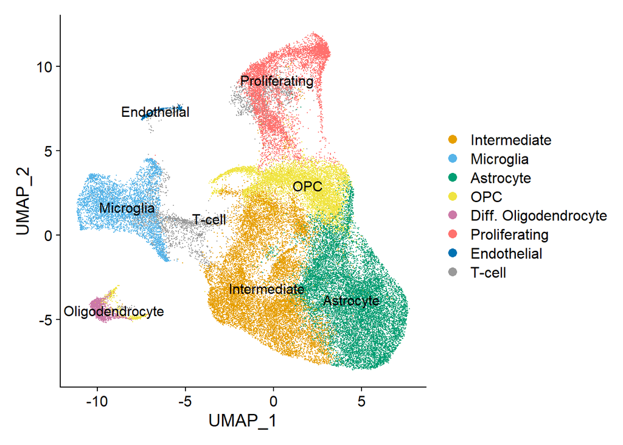

```r
cbPalette <- c("#E69F00", "#56B4E9", "#009E73", "#F0E442",
               "#CC79A7", "#ff716e", "#0072B2", "#999999",
               "#194c76", "#D55E00", "#4C4E52")
ge <- SetIdent(ge, value = ge@meta.data$int04_celltypes)
p <- DimPlot(ge, label=TRUE, cols = cbPalette)
p
```

```r
# ggsave("fig_gbmscte_ge_PC20r04_UMAP_celltypes_labels.tiff", plot = p, units="in", width=size*1.4, height=size*1, dpi=300, compression = 'lzw')
```

### Dot Plot Summarizing known markers by cell type

```r
DefaultAssay(ge) <- "integrated"
ge@meta.data$int04_celltypes <- factor(ge@meta.data$int04_celltypes,
                                       levels = c(
                                         "Astrocyte",
                                         "OPC",
                                         "Diff. Oligodendrocyte",
                                         "Microglia",
                                         "Proliferating",
                                         "Endothelial",
                                         "T-cell",
                                         "Intermediate"
                                       ))
ge <- SetIdent(ge, value = ge@meta.data$int04_celltypes)
features <- c(#"HBB", #Blood
              "CD3E", #"CD8A", #T-cells
              "FLT1", "VWF", "FN1", #Endothelial
              #"ASCL1", # IPC-late (?)
              #"PVALB", "SST", "GAD1", # Differentiated Cortical Interneurons (Inhibitory neurons)
              "MKI67", "MCM6", "TOP2A", "PCNA",  #Proliferating Cell Type
              "PTPRC", "C1QC", "CD68", "TREM2", "GPR34", "CSF1R", "CX3CR1", #Microglia,
                #"P2RY12", "HEXB" were absent
              "MYRF", "MBP", "MOG", "PLP1", #Oligodendrocytes
              "OLIG1", "OLIG2", "PDGFRA", "SOX10",  #OPC, "COL20A1" was absent
              "GFAP", "AQP4", "HOPX", "SLC1A2" #Astrocytes
              #"HES1" #NPC
             )

p <- DotPlot(ge, features = features) +   scale_colour_gradient2() +
      xlab("Known Brain Cell Markers") + ylab("Cell Types") + coord_flip() +
      theme(axis.text.x = element_text(angle = 40, vjust = 1, hjust=1))
```

```
## which will replace the existing scale.
```

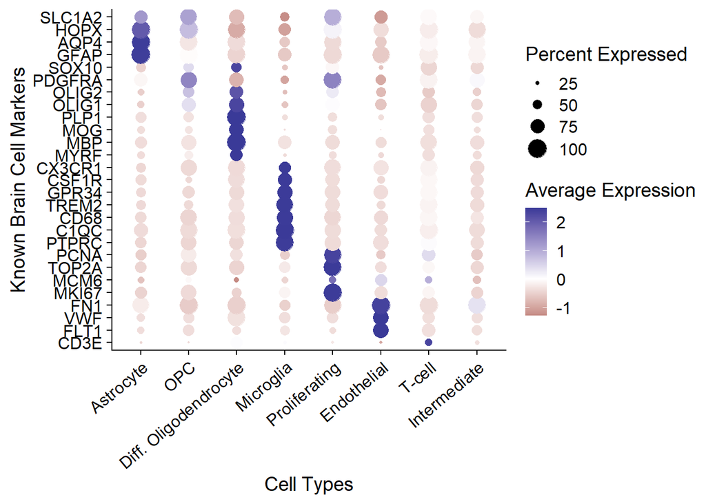

```r
p
```

```r
# ggsave("fig_gbmscte_ge_dotplot_summary_int_celltypes.tiff", plot = p, units="in", width=size*1.1, height=size*1.3, dpi=300, compression = 'lzw')
```

### Unload data

```r
rm(ge)
gc()
```

```
##             used   (Mb) gc trigger   (Mb)   max used   (Mb)
## Ncells   3567701  190.6    6227361  332.6    6227361  332.6
## Vcells 558298418 4259.5 1237192941 9439.1 1162876839 8872.1
```